# Multitype Branching Processes

Jackson Van Vooren

March 1, 2024

## Prerequisites

You should be familiar with the basic theory of single-type branching processes, which is presented in the **Theory of Branching Processes** vignette.

## Introduction

We have already explored the growth of a population through a Galton Watson process. Now, let us extend that theory to a branching process with multiple types of individuals (assuming, for example, heterogeneity in the gene pool).

To illustrate, say we have a population where individuals are classified into $3$ types: type `AA`, `Aa`, and `aa` (i.e. whether they are homozygous dominant, recessive, or heterozygous). Assume that each of these types vary in their level of fitness. So, `AA` might be more likely to have more offspring. Similarly, we also can assume different probabilities of a parent having each offspring type. That is, an individual of type `aa` would be more likely to have an offspring of type `aa`.

The overarching assumptions that the parent dies after birth and that we do not distinguish between sex still apply. A plausible approach, then, is looking at only the female children from its mother.

This vignette develops the theory of a multitype branching process, extending what has already been covered in the single type case.

## Mathematical Setup

Let $m$ be the number of types. For a standard population genetics model, where each individual can either have genotype *AA*, *Aa*, or *aa*, then $m=3$.

Let
$$\mathbf{Z}_n = (Z_n^1, Z_n^2, \dots,
Z_n^m)$$
be the $m$ dimensional vector that has the number of individuals of each type in generation $n$. Therefore, the total population in generation $n$ is the sum,
$$\sum_{k=1}^{m} Z_n^{k}.$$

Assume that $\mathbf{Z}_0 = (1, 1, \dots, 1)$. We now define the offspring vector, $\mathbf{k} = (k_1, \dots, k_m)$ with $1\leq i \leq m$. Here, $k_i$ is the number of offspring of the $i$th type. So, for an individual of type $i$, $p_i(\mathbf{k})$ is the probability that individual has the entire offspring vector $\mathbf{k}$. The sum over all offspring vectors is $1$, i.e., $\sum_{\mathbf{k}}p_i(\mathbf{k}) = 1$.

## Generating Functions with Multiple Types

Recall that in the singular Galton Watson process, the probability generating function is defined by $\phi(s) = \sum_{k}^{\infty} p_k s^k$. To generalize, for a vector $\mathbf{s} = (s_1, s_2, \dots, s_m)$, each individual $i$, $1 \leq i \leq m$ has its own PGF, given by,
$$\phi_i(\mathbf{s}) = \sum_{\mathbf{k}}
p_i(\mathbf{k})s_1^{k_1} \dots s_m^{k_m}$$

$\phi(s)$, then, is a vector-valued function,
$$\phi(s) =
\left(\phi_1(s), \dots, \phi_m(s)\right) = \left(\sum_{\mathbf{k}}
p_1(\mathbf{k})s_1^{k_1} \dots s_m^{k_m} \;, \dots,\; \sum_{\mathbf{k}}
p_m(\mathbf{k})s_1^{k_1} \dots s_m^{k_m}\right)$$

For a multitype branching process to become extinct, we must expect that all types eventually go extinct. That is, a population goes extinct if there exists $N\in\mathbb{N}$ such that $\mathbf{Z}_n = \mathbf{0} = (0, \dots, 0)$ for all $n \geq N$ and for all $1 \leq i \leq m$.

In the single type case, we solve $\phi(s)=s$ to find the extinction probability. In the multi-type case, different types do not generally have the same extinction probability, as some are more fit to reproduce than others. So, we construct a vector of extinction probabilities,
$$\mathbf{P}_e = (P_e^1, P_e^2, \dots,
P_e^m).$$
For each type $i$, we have
$$P_e^i =
\phi_i(\mathbf{P}_e).$$

The proof of this is similar to the single type case, but relies more heavily on measure theory. A detailed proof is presented in [Harris](https://www.rand.org/content/dam/rand/pubs/reports/2009/R381.pdf) (Theorem 7.1 on page 41).

As expected, the multitype Galton Watson process forms a Markov chain with static transition probabilities. We assume all individuals reproduce independently, and offspring distributions do not change across generations, so $\mathbf{Z}_n$ depends only on $\mathbf{Z}_{n-1}$.

## Illustrative Biological Example

In this section, we construct a multitype branching process with 3 types in an attempt to determine the extinction probabilities of the process.

### Probabilities

Let’s say we have a population with 3 types: genotypes `AA`, `Aa`, and `aa`. An individual of type `AA` has a $0.2$ probability of having $0$ offspring, $0.5$ chance of $1$ offspring, and $0.3$ chance of having $2$ offspring. We similarly define the probabilities of type `Aa` and `aa` having $0$, $1$, or $2$ offspring.

$$\begin{array}{c|c|c|c}
& 0 \text{ offspring} & 1 \text{ offspring} & 2 \text{
offspring}\\
\hline
\text{Type AA} & 0.2 & 0.5 & 0.3 \\
\hline
\text{Type Aa} & 0.2 & 0.2 & 0.6 \\
\hline
\text{Type aa} & 0.8 & 0.1 & 0.1 \\
\end{array}$$

Here, we assume type `aa` is less fit, with most individuals having no offspring. We would expect this type to go extinct first.

```r
num_offspring_probs <- list(
  AA = c(0.2, 0.5, 0.3),
  Aa = c(0.2, 0.2, 0.6),
  aa = c(0.8, 0.1, 0.1)
)
```

The rows represent the parent’s type, and conditional on if they have an offspring, the columns are the distribution of the offspring type.

$$\begin{array}{c|c|c|c}
& \text{Type AA} & \text{Type Aa} & \text{Type aa}\\
\hline
\text{Type AA} & 0.6 & 0.4 & 0 \\
\hline
\text{Type Aa} & 0.2 & 0.6 & 0.2 \\
\hline
\text{Type aa} & 0 & 0.2 & 0.8 \\
\end{array}$$

For example, this asserts that a homozygous recessive individual cannot have a homozygous dominant offspring.

```r
offspring_type_probs <- list(
  AA = c(0.6, 0.4, 0),
  Aa = c(0.2, 0.6, 0.2),
  aa = c(0, 0.2, 0.8)
)
```

### Simulate population

To simulate a single generation of the population, we assume we begin with one individual of each type. Then, we sample based on the probability distributions above to determine how many offspring each individual has. We then assign these individuals a type based on the distribution of their parent.

```r
population <- list(AA = 1, Aa = 1, aa = 1) #Initialize

# Simulate a single generation of population growth
simulate_generation <- function(population, num_offspring_probs, offspring_type_probs) {
  new_population <- list(AA = 0, Aa = 0, aa = 0)

  for (type in names(population)) {
    # Determine number of offspring per individual
    num_offspring <- sample(0:2, size = population[[type]],
                            replace = TRUE, prob = num_offspring_probs[[type]])

    # Determine type of each offspring
    for (i in seq_along(num_offspring)) {
      offspring_type <- sample(c("AA", "Aa", "aa"), size = num_offspring[i],
                               replace = TRUE, prob = offspring_type_probs[[type]])

      # Update the population numbers
      for (otype in offspring_type) {
        new_population[[otype]] <- new_population[[otype]] + 1
      }
    }
  }
  return(new_population)
}
```

Simulating 10 generations, we find the total number of individuals of each type at each generation $t\in \mathbb{N} \cup \{0\}$, $0 \leq t \leq 10$.

```r
num_generations <- 10
results <- list()
results[[1]] <- population

for (gen in 2:(num_generations + 1)) {
  new_population <- simulate_generation(population, num_offspring_probs, offspring_type_probs)
  results[[gen]] <- new_population
  population <- new_population
}

for (gen in seq_along(results)) {
  cat("Generation", gen - 1, ":", "AA =", results[[gen]]$AA,
                                  ", Aa =", results[[gen]]$Aa,
                                  ", aa =", results[[gen]]$aa, "\n")
}
```

```
Generation 0 : AA = 1 , Aa = 1 , aa = 1
Generation 1 : AA = 0 , Aa = 2 , aa = 0
Generation 2 : AA = 1 , Aa = 2 , aa = 1
Generation 3 : AA = 0 , Aa = 5 , aa = 1
Generation 4 : AA = 0 , Aa = 4 , aa = 2
Generation 5 : AA = 1 , Aa = 2 , aa = 3
Generation 6 : AA = 3 , Aa = 1 , aa = 1
Generation 7 : AA = 3 , Aa = 2 , aa = 0
Generation 8 : AA = 2 , Aa = 3 , aa = 2
Generation 9 : AA = 6 , Aa = 3 , aa = 0
Generation 10 : AA = 6 , Aa = 7 , aa = 1
```

For example, in Generation 6, there are 5 individuals total, 3 of type AA and 1 each of type Aa and aa.

### Graphing Population Growth

Because the population does not follow a known probability distribution, let’s simulate more generations to understand the change of the population over time.

```r
num_generations <- 30
results <- list()
results[[1]] <- population

for (gen in 2:(num_generations + 1)) {
  new_population <- simulate_generation(population, num_offspring_probs, offspring_type_probs)
  results[[gen]] <- new_population
  population <- new_population
}
```

Graphing both the growth of each type and the population as a whole, we have,

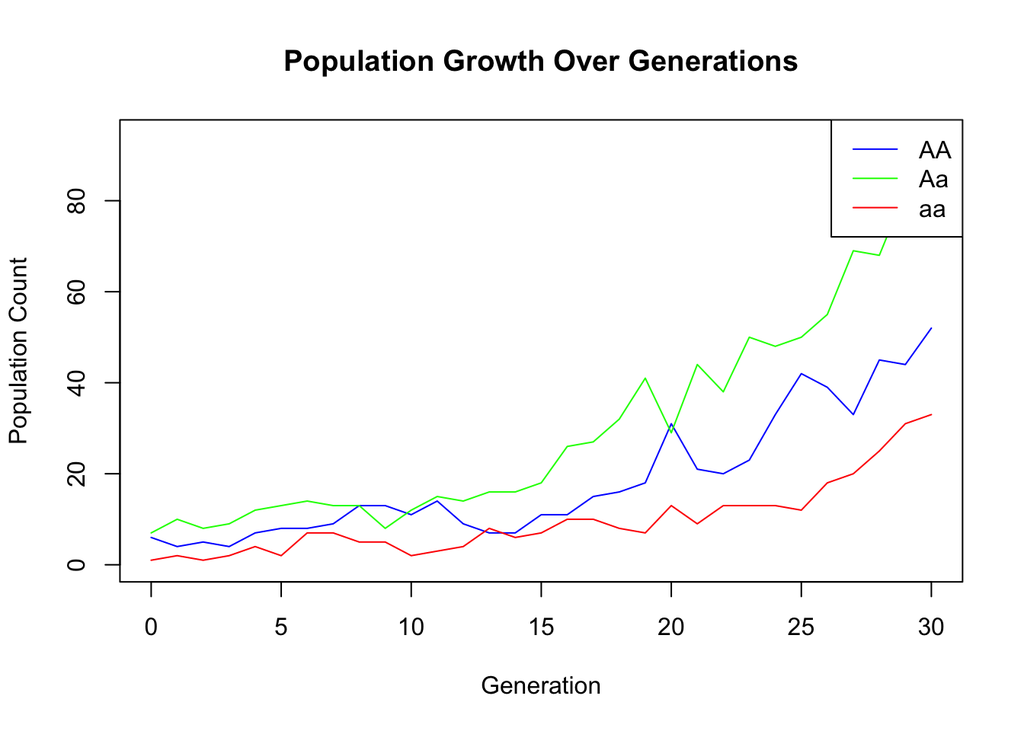

```r
population_df <- as.data.frame(do.call(rbind, lapply(results, unlist)))
population_df$Generation <- 0:(num_generations)

plot(population_df$Generation, population_df$AA, type = "l", col = "blue",
         xlab = "Generation", ylab = "Population Count",
         main = "Population Growth Over Generations",
         ylim = c(0, max(population_df$AA, population_df$Aa, population_df$aa)))
lines(population_df$Generation, population_df$Aa, col = "green")
lines(population_df$Generation, population_df$aa, col = "red")
legend("topright", legend = c("AA", "Aa", "aa"), col = c("blue", "green", "red"), lty = 1)
```

Heterozygotes ‘’do the best’’, having the most number of members in the population. Homozygous recessive individuals seem to do the worst in reproduction numbers, and they have the slowest growth.

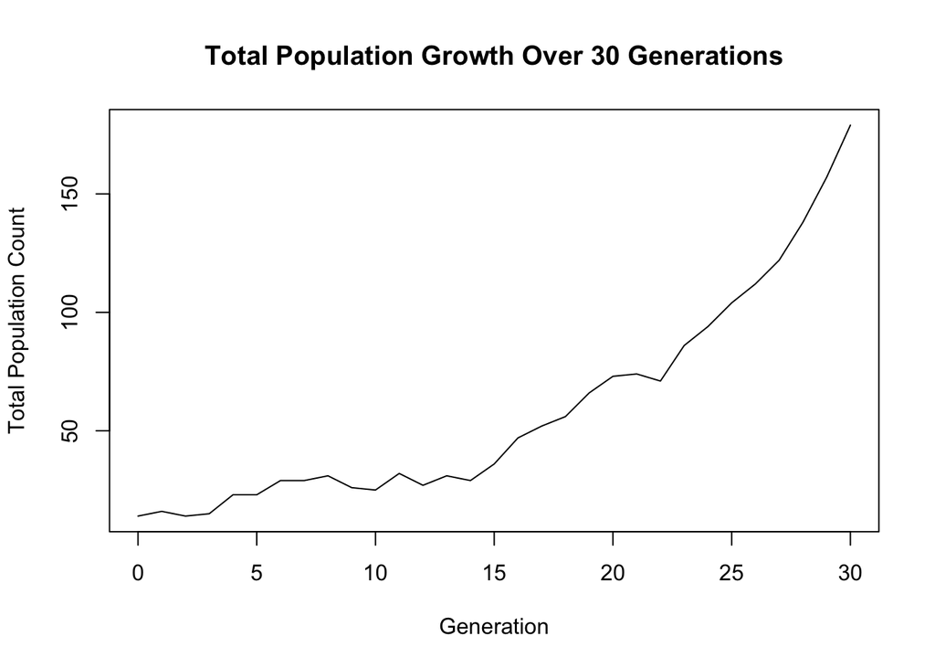

```r
population_df$Total <- population_df$AA + population_df$Aa + population_df$aa

plot(population_df$Generation, population_df$Total, type = "l",
         col = "black", xlab = "Generation", ylab = "Total Population Count",
         main = "Total Population Growth Over 30 Generations")
```

### Extinction Probabilities

There is now a vector of 3 extinction probabilities, one for each type. This is because we assume `AA`, `Aa`, and `aa` all reproduce independently and at different success rates, so some are more likely to go extinct. The population goes extinct only if all three types do, as well.

In practice, find the vector $\mathbf{P}_e$ is difficult. Even solving for a single type’s $P_e^i$, which must satisfy $\phi_i(P_e^i) = P_e^i$ is no easy task. Recall that in the generating function, $\phi_i(\mathbf{s}) = \sum_{\mathbf{k}} p_i(\mathbf{k})s_1^{k_1} \dots s_m^{k_m}$. we sum over all possible offspring vectors $\mathbf{k}$. In the current example, $\mathbf{k} = (k_{AA}, k_{Aa}, k_{aa})$, where $k_{Aa}$ is the number of offspring of type `Aa`. Some possible offspring vectors include:

$$(0,0,0)\quad(1,0,1)\quad(0,1,1)\quad(2,0,0)\quad(0,0,2)\quad(0,1,1)\quad(0,2,0)\quad(1,1,0)$$
and so on. We must calculate the probability that each individual of type $i$ has this vector. For example, the probability that an individual of type `AA` has one offspring of type `AA` and one offspring of type `Aa` is:
$$P_{AA}((1,1,0)) =
\mathbb{P}[\text{ AA has } 2 \text{ offspring, 1 is AA, 1 is Aa
}]$$
Let’s not go through with the calculations; this method of determining the extinction probabilities is quite impractical. If we have more than $3$ types and the total number of offspring is not capped at $2$, there could quickly be hundreds of offspring vectors to sum over.

Suppose we are only interested in determining if the entire population will go extinct. We can use a Monte Carlo estimator by taking the mean of many simulations of this population. We assume that, if a population has not gone extinct within $50$ generations, then it will persist into perpetuity.

NB: Computationally, as growth becomes more exponential, more generations take an absurdly long time to simulate.

```r
num_simulations <- 1000
extinction_count <- 0

for (sim in 1:num_simulations) {
  population <- list(AA = 1, Aa = 1, aa = 1)

  for (gen in 1:50) {
    population <- simulate_generation(population, num_offspring_probs, offspring_type_probs)

    if (population$AA == 0 && population$Aa == 0 && population$aa == 0) {
      extinction_count <- extinction_count + 1
      break
    }
  }
}
cat("Number of extinctions:", extinction_count, "\n")
```

```
Number of extinctions: 434
```

We observe $434$ extinctions out out of $1000$, so a Monte Carlo estimate for the extinction probability of the entire population is $0.434$.

Recall in the single type case, we defined supercritical, subcritical, and critical branching processes (respectively, $\mu > 1$, $\mu < 1$, and $\mu = 1$). In these, with the offspring distribution alone, we are able to determine if the population is destined for extinction. In the multitype case, though, we do not have a singular $\mu$ value, and must instead examine the mean matrix, which I denote $A$.

### Multitype Mean Matrix

The most crucial addition to the theory of a multitype branching process is that of the associated mean matrix, $A$. This is the matrix of mean offspring for each type. We have
$$a_{ij} =
\mathbb{E}[Z_1^{j} \;|\; Z_0^{i} = 1].$$
That is, each $a_{ij}$ is the expected number of individuals of type $j$ given we start with a single individual of type $i$.
$$A =
(a_{ij})_{\;i,\; j \;=\; 1 \dots m}$$

Let’s calculate the matrix $A$ for this example. The expected number of offspring of type `AA` is $\mathbb{E}[\text{# offspring of type AA}] = 0 \cdot 0.2 + 1 \cdot 0.5 + 2 \cdot 0.3 = 1.1$. Now, of these $1.1$ individuals, $1.1 \cdot 0.6 = 0.66$ have type `AA`, $1.1\cdot 0.4 = 0.44$ have type `Aa` and $0$ are expected to be of type `aa`. Continuing with types `Aa` and `aa`, we find

$$\begin{array}{c|c|c|c}
& \text{Type AA} & \text{Type Aa} & \text{Type aa}\\
\hline
\text{Type AA} & 0.66 & 0.44 & 0 \\
\hline
\text{Type Aa} & 0.28 & 0.84 & 0.28 \\
\hline
\text{Type aa} & 0 & 0.06 & 0.24 \\
\end{array}$$

We have the matrix,

```r
mean_matrix <- matrix(c(0.66, 0.44, 0,
                        0.28, 0.84, 0.28,
                        0, 0.06, 0.24), nrow = 3, byrow = TRUE)
```

There are also several relationships between the mean matrix and the probability generating function of the multitype process, presented in [McCorvie](https://mccorvie.org/files/hawkes_branching_processes.pdf). Letting $\phi_i(\mathbf{s})$ be the generating function for each individual $i$, some of these properties include:

1. $\quad a_{ij} = \dfrac{\partial g_i}{\partial s_j} ((1,1,\dots,1))$
2. $\quad \mathbb{E}[\mathbf{Z}_n | \mathbf{Z_0}] = \mathbf{Z}_0 \mathbf{M}^n$

If there is an $n\in\mathbb{N}$ such that every entry of $A^n$ is positive, $A^n$ is positive regular. Luckily, in our example, $A^2$ is strictly positive.

```r
mean_matrix %*% mean_matrix
```

```
       [,1]   [,2]   [,3]
[1,] 0.5588 0.6600 0.1232
[2,] 0.4200 0.8456 0.3024
[3,] 0.0168 0.0648 0.0744
```

Also, $A$ is invertible because the determinant is non-zero.

```r
det(mean_matrix)
```

```
[1] 0.0924
```

This allows us to apply the following result. If $A$ is invertible and positive regular, then consider the largest eigenvalue of $A$, $\lambda_{\text{max}}$.

- If $\lambda_{\text{max}} > 1$, then the extinction probability vector $\mathbf{P}_e < \mathbf{1}$,
- If $\lambda_{\text{max}} \leq 1$, then extinction occurs with probability $\mathbf{1}$.

The multitype branching process is supercritical, subcritical, or critical, based on the largest eigenvalue of $A$, $\lambda_{\text{max}}$.

I defer the proof to [Harris’s textbook](https://www.rand.org/content/dam/rand/pubs/reports/2009/R381.pdf) and solve for the largest eigenvalue of the mean matrix.

```r
eigenvalues <- eigen(mean_matrix)$values
print(max(Re(eigenvalues)))
```

```
[1] 1.124327
```

Since $\lambda_{\text{max}} = 1.12 > 1$, this process is supercritical and the probability of extinction of the population is less than $(1, 1, 1)$ in at least one of the components. Below, I present a more simplified example where we can explicitly solve for each extinction probability of the types using $\phi^i(\mathbf{s}) = \mathbf{s}$.

## Closed Form Example

We again consider a Galton Watson process with $3$ types, `AA`, `Aa`, and `aa`. We have the following generating functions, which greatly restrict the potential offspring vectors, $\mathbf{k}$.
$$\begin{align*}
\phi_{AA}((s_1, s_2, s_3)) &= \frac{5}{8}s_{AA}^2 +
\frac{3}{8}s_{Aa}\\
\phi_{Aa}((s_1, s_2, s_3)) &= \frac{10}{33} +
\frac{14}{33}s_{AA}s_{aa} + \frac{9}{33}s_{Aa}^2\\
\phi_{aa}((s_1, s_2, s_3)) &= \frac{3}{8}s_{Aa} +
\frac{5}{8}s_{aa}^2\\
\end{align*}$$

Using property 1, that $a_{ij} = \dfrac{\partial g_i}{\partial s_j} ((1,1,\dots,1))$, we get the mean matrix to be

$$A=
\begin{pmatrix}
\frac{10}{8} & \frac{3}{8} & 0\\
\frac{14}{33} & \frac{18}{33} & \frac{14}{33}\\
0 & \frac{3}{8} & \frac{10}{8}
\end{pmatrix}$$

```r
mean_matrix <- matrix(c(10/8, 3/8, 0,
                        14/33, 18/33, 14/33,
                        0, 3/8, 10/8), nrow = 3, byrow = TRUE)
```

This matrix is indeed positive regular and invertible.

```r
mean_matrix %*% mean_matrix
```

```
          [,1]      [,2]      [,3]
[1,] 1.7215909 0.6732955 0.1590909
[2,] 0.7617080 0.6157025 0.7617080
[3,] 0.1590909 0.6732955 1.7215909
```

```r
det(mean_matrix)
```

```
[1] 0.4545455
```

The largest eigenvalue, $\lambda_{\text{max}}$, can be found as follows:

```r
eigenvalues <- eigen(mean_matrix)$values
print(max(Re(eigenvalues)))
```

```
[1] 1.562767
```

Since $1.56>1$, this branching process is supercritical and there is a solution to $\phi_i(\mathbf{s}) = s_i$ for each $i = AA, Aa, aa$ and $\mathbf{s} = (s_{AA}, s_{Aa}, s_{aa})$.

1. For $i = AA$:
   $$\frac{5}{8}s_{AA}^2 - s_{AA} + \frac{3}{8}s_{Aa} = 0$$
2. For $i = Aa$:
   $$\frac{9}{33}s_{Aa}^2 - s_{Aa} + \frac{14}{33}s_{AA}s_{aa} +
   \frac{10}{33} = 0$$
3. For $i = aa$:
   $$\frac{5}{8}s_{aa}^2 - s_{aa} + \frac{3}{8}s_{Aa} = 0$$

```r
phi_AA <- function(s_AA, s_Aa, s_aa) {return(5/8 * (s_AA^2) - s_AA + 3/8 * s_Aa)}
phi_Aa <- function(s_AA, s_Aa, s_aa) {return(9/33 * (s_Aa^2) - s_Aa + 14/33 * s_AA * s_aa + 10/33)}
phi_aa <- function(s_AA, s_Aa, s_aa) {return(5/8 * (s_aa^2) - s_aa + 3/8 * s_Aa)}
```

Using R’s `optim` method, we can minimize the sum of squares to find the solutions such that all three functions are as close to $0$ as possible.

```r
objective <- function(x) {
  s_AA <- x[1]
  s_Aa <- x[2]
  s_aa <- x[3]
  phi_AA_val <- phi_AA(s_AA, s_Aa, s_aa)
  phi_Aa_val <- phi_Aa(s_AA, s_Aa, s_aa)
  phi_aa_val <- phi_aa(s_AA, s_Aa, s_aa)
  return(phi_AA_val^2 + phi_Aa_val^2 + phi_aa_val^2)
}

initial_guess <- c(0.1, 0.1, 0.1)
result <- optim(initial_guess, objective)

s_AA_solution <- result$par[1]
s_Aa_solution <- result$par[2]
s_aa_solution <- result$par[3]
```

```r
cat(paste("s_AA:", s_AA_solution), "\n")
```

```
s_AA: 0.141439516958145
```

```r
cat(paste("s_Aa:", s_Aa_solution), "\n")
```

```
s_Aa: 0.343755789454065
```

```r
cat(paste("s_aa:", s_aa_solution))
```

```
s_aa: 0.141403977212524
```

So, $\mathbf{s} = (0.1414, 0.3438, 0.1414)$ satisfies $\phi(\mathbf{s}) = \mathbf{s}$. Finally, we check the solutions to make sure that they satisfy $\phi_i(\mathbf{s}) = s_i$. As expected, each $\phi_i(\mathbf{s}) - s \approx 0$.

```r
phi_AA(s_AA_solution, s_Aa_solution, s_aa_solution)
```

```
[1] -2.788531e-05
```

```r
phi_Aa(s_AA_solution, s_Aa_solution, s_aa_solution)
```

```
[1] -1.294314e-05
```

```r
phi_aa(s_AA_solution, s_Aa_solution, s_aa_solution)
```

```
[1] 1.371815e-06
```

## Closing Remarks

This vignette extended the theory of single type Galton Watson processes to multitype branching processes, which allows for unique offspring distributions based on allele combinations. Much of the theory is analogous, and accounts for different vectors of probabilities depending on the type.

In sum, these three vignettes offer a comprehensive exploration of branching processes, particularly relevant in modeling population growth in biological systems. By examining concepts such as extinction probabilities, offspring distributions, and their connection to allele frequencies, we gain insights into the dynamics of evolving populations. The assessment of extinction probabilities could potential allow researches to buffer populations against environmental uncertainties and stochastic events.